# Prediction Intervals

Dr. Josh Jacobson

4 February 2026

*These lecture notes were originally developed by Dr. Kris Pruitt.*

The purpose of this lesson is to construct confidence intervals and prediction intervals for an estimated response value.

# Point Estimate for the Response

After estimating the parameters of a multiple linear regression model, we often want to predict the response for a given set of explanatory variable values. Specifically, for a given set of values $(x_1,x_2,\cdots,x_p)$ we compute a point estimate $\hat{y}$ using the following formula:

$$\hat{y}=\hat{\beta}_0 + \hat{\beta}_1x_1 + \hat{\beta}_2x_2 + ... +
\hat{\beta}_px_p$$

Let’s demonstrate point estimates with an example. Import and split the NBA data using the code below. We will choose 75% for training and 25% for testing.

```r
# import data
nba <- read_csv("basketball.csv") %>%
  select(MOV, X1PP, X2PP, X3PP) %>%
  na.omit()

# randomly select training rows
set.seed(303)
rows <- sample(x = nrow(nba), size = floor(0.75 * nrow(nba)), replace = FALSE)

# extract training and testing sets
training <- nba[rows, ]
testing <- nba[-rows, ]
```

Fit a model to predict margin of victory using the three shooting percentages.

```r
# fit regression model
model <- lm(MOV ~ ., data = training)

# summarize model output
summary(model)
```

```
##
## Call:
## lm(formula = MOV ~ ., data = training)
##
## Residuals:
##     Min      1Q  Median      3Q     Max
## -46.966  -8.194   0.154   8.323  34.081
##
## Coefficients:
##             Estimate Std. Error t value Pr(>|t|)
## (Intercept)  -66.346      4.887 -13.575   <2e-16 ***
## X1PP           8.133      4.364   1.864   0.0628 .
## X2PP          70.805      5.893  12.015   <2e-16 ***
## X3PP          69.219      4.953  13.975   <2e-16 ***
## ---
## Signif. codes:  0 '***' 0.001 '**' 0.01 '*' 0.05 '.' 0.1 ' ' 1
##
## Residual standard error: 11.84 on 745 degrees of freedom
## Multiple R-squared:  0.3136, Adjusted R-squared:  0.3109
## F-statistic: 113.5 on 3 and 745 DF,  p-value: < 2.2e-16
```

The resulting prediction model includes the following parameter values.

$$\hat{y}=-66.35 + 8.13x_1 + 70.81x_2 + 69.22x_3$$

The RSE is around 12 points and the R-squared is about 31%. Now, suppose we wish to predict the first observation in the testing set.

```r
# show first test observation
testing[1, 2:4]
```

| X1PP | X2PP | X3PP |
| --- | --- | --- |
| 0.6538462 | 0.64 | 0.2564103 |

We could predict the margin of victory $\hat{y}_*$ for these specific shooting percentages manually. Here we include an asterisk to indicate this prediction is for a specific observation.

```r
# manually predict MOV
-66.35 + 8.13 * 0.6538 + 70.81 * 0.64 + 69.22 * 0.2564
```

```
## [1] 2.031802
```

Alternatively, we could use the `predict()` function.

```r
# automatically predict MOV
predict(model, newdata = testing[1, 2:4])
```

```
##        1
## 2.035455
```

The small difference in our predictions is due to rounding the entries in the manual approach. Regardless, our best point estimate $\hat{y}_*$ for a team with the listed shooting percentages is a margin of victory around 2 points. However, this prediction is dependent on the parameter estimates of the model, which are in turn dependent on the sample data. Different samples result in different parameter estimates and, therefore, different predictions for the same input values. This alludes to the concept of confidence intervals for the response.

# Confidence Interval for the Response

Just as we can construct confidence intervals for the coefficients of our linear model, we can do the same for the predicted response. In the following code we resample observations, with replacement, from the training data and fit a new model each iteration. Then, we predict the same observation from the testing data and save the associated estimate. This provides a sampling distribution for the mean response.

```r
# initiate empty vector
results <- data.frame(y_hat = rep(NA, 2000))

# repeat bootstrap process 1000 times and save results
for (i in 1:2000) {
  set.seed(i)
  nba_boot <- sample_n(training, size = 749, replace = TRUE)

  model_boot <- lm(MOV ~ ., data = nba_boot)

  results$y_hat[i] <- predict(model_boot, newdata = testing[1, 2:4])
}
```

Once we have enough predictions for a sampling distribution, we can depict it in a histogram along with the bounds of a 90% confidence interval.

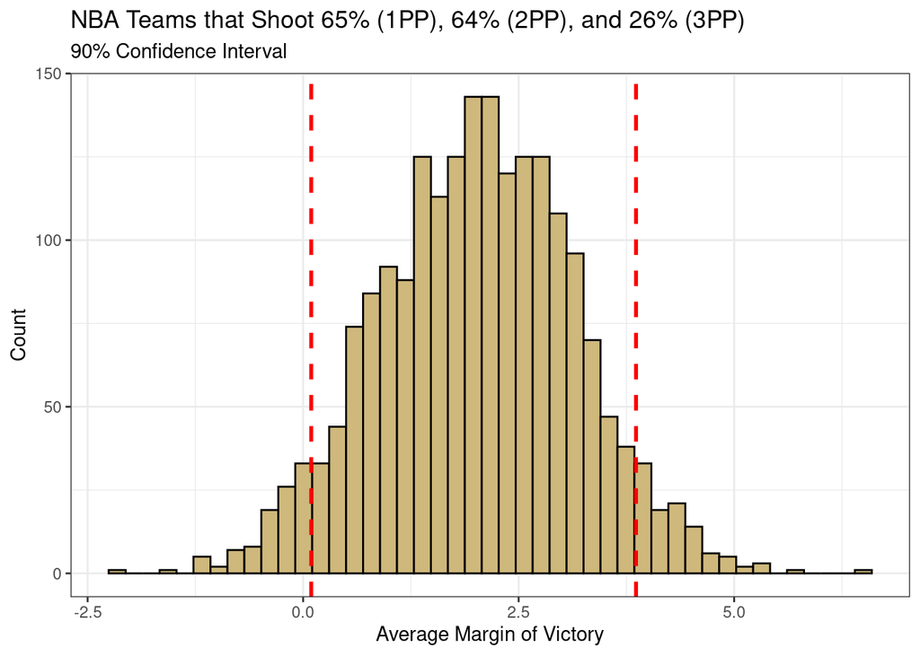

```r
# plot bootstrap distribution
ggplot(data = results, aes(x = y_hat)) +
  geom_histogram(color = "black", fill = "#CFB87C", bins = 45) +
  geom_vline(
    xintercept = quantile(results$y_hat, probs = 0.05),
    linetype = "dashed", color = "red", linewidth = 1
  ) +
  geom_vline(
    xintercept = quantile(results$y_hat, probs = 0.95),
    linetype = "dashed", color = "red", linewidth = 1
  ) +
  labs(
    title = "NBA Teams that Shoot 65% (1PP), 64% (2PP), and 26% (3PP)",
    subtitle = "90% Confidence Interval",
    x = "Average Margin of Victory",
    y = "Count"
  ) +
  theme_bw()
```

For *all* teams that shoot 65% for free-throws, 64% for two-pointers, and 26% for three-pointers, we are 90% confident that the average margin of victory is between 0.09 and 3.9 points. Notice that zero is not in this interval. Thus, we are relatively confident that the *average* team with these shooting percentages will win.

We can construct the same interval using mathematical theory, which assumes a t-distribution for the standard error. The confidence interval formula follows the standard structure of point estimate plus or minus a margin of error.

$$\hat{y}_* \pm t_{\alpha/2,n-1-p} \cdot SE_{\hat{y}_*}$$

Our point estimate for the mean response ($\hat{y}_*$) given a particular vector of explanatory values ($X_*$) uses the fitted model. The number ($t_{\alpha/2,n-1-p}$) of standard errors depends on the significance level and degrees of freedom. Finally, the standard error for the mean response is calculated as follows.

$$SE_{\hat{y}_*}= \sqrt{\text{MSE} \cdot (X_*^T(X^TX)^{-1}X_*)}$$

The mean squared error (MSE) is the estimate for the true error variance $\sigma^2$. The larger the error variance, the wider our confidence interval. The remaining term accounts for the distance of the observation of interest $X_*^T = (1, \; x_{11*}, \; x_{12*} , \cdots , \; x_{1p*})$ from the center (mean) of the training data $X$. The further the observation from the center of the data, the wider our confidence interval. Why do you think this is the case?

Luckily, we do not need to compute these values by hand. The `predict()` function includes an option for a confidence interval.

```r
# compute confidence interval
predict(model,
  newdata = testing[1, 2:4],
  interval = "confidence", level = 0.9
)
```

```
##        fit       lwr      upr
## 1 2.035455 0.2687535 3.802156
```

The bounds of this interval are very similar to those we found computationally. The differences are due to the assumption of the t-distribution in the second method. In the simple linear regression case, these confidence bands are exactly what we observe when using the `geom_smooth()` function in a scatter plot. The benefit is that we get the bounds for all explanatory values rather than just one.

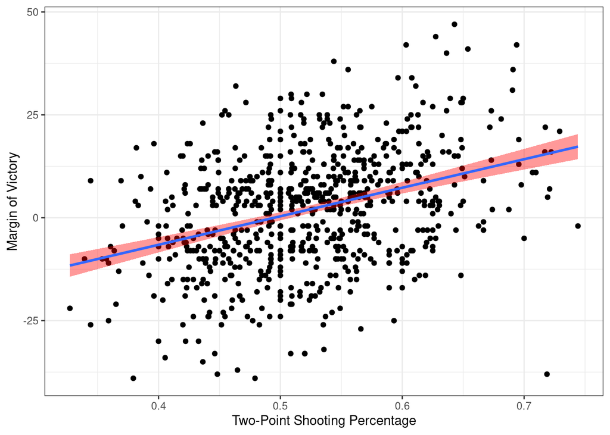

```r
ggplot(data = training, aes(x = X2PP, y = MOV)) +
  geom_point() +
  geom_smooth(
    formula = y ~ x,
    method = "lm",
    se = TRUE,
    fill = "red"
  ) +
  labs(
    x = "Two-Point Shooting Percentage",
    y = "Margin of Victory"
  ) +
  theme_bw()
```

Where does it appear that the confidence intervals are the widest? Why is this the case?

# Prediction Interval for the Response

Throughout the previous section, we consistently referred to predicting the *mean* response. This is a subtle but important point. A confidence interval for the response estimates the average margin of victory for *all* teams that have the given predictor values. For example, if 100 teams shoot 65% for free-throws, 64% for two-pointers, and 26% for three-pointers, then we would predict the average margin of victory across all 100 teams to be between 0.27 and 3.80 points. This is *not* the same as predicting the margin of victory for the *next* team that has these shooting percentages.

If we want to predict the response for the *next* observation, the width of the interval will be much greater. There is much more variability associated with predicting a single response than the average response. Consequently, the standard error formula changes to the following.

$$SE_{\hat{y}_*^{pred}}= \sqrt{\text{MSE} + SE_{\hat{y}_*}^2}$$

When this new standard error is used, we refer to the estimate as a **prediction interval**. Prediction intervals estimate an individual response, whereas confidence intervals estimate the average response. The `predict()` function handles the computation for us.

```r
# compute confidence interval
predict(model,
  newdata = testing[1, 2:4],
  interval = "prediction", level = 0.9
)
```

```
##        fit       lwr      upr
## 1 2.035455 -17.54835 21.61926
```

Thus, the next team that shoots 65% for free-throws, 64% for two-pointers, and 26% for three-pointers would be predicted to have a margin of victory between -17.5 and 21.6. For an individual team, it is unclear whether these shooting percentages would result in victory or defeat because the prediction interval includes zero.

Both types of intervals employ the same point estimate (i.e., 2.04 points) and number of standard errors on the t-distribution. However, the standard error itself is much larger for prediction intervals compared to confidence intervals. This is due to averages having lower variability than individual values.